# Climate Change and its effect on Maple Syrup Production in the US

*Maple Syrup* production has been a tradition for many American States since the 1500's. The first ever documentation of maple syrup production was done in 1557 by French explorer André Thévet *(The History of Maple Syrup: From Early North American Days to the Present - Coombs Family Farms, n.d.)*. Since the 1800's there have been rapid advancements in farming and production techonologies, which lead to the US being one of the largest Maple Syrup producers in the world. The process of 'farming' maple syrup is a long time-sensitive and temperature-sensitive process. Here is a short overview of maple syrup production from the start:

1. [Spiles](https://practicalselfreliance.com/wp-content/uploads/2018/01/Maple-Syrup-Tap.jpg) are inserted into trees and are left to collect the sap from inside the tree
2. The collected sap is taken to a sugarhouse immediately through a vacuum pump
3. Some water is removed from the sap through a [reverse osmosis machine](https://media.sciencephoto.com/image/c0360245/800wm/C0360245-Maple_syrup_production,_reverse_osmosis_machine.jpg)
4. the remaining sap is then boiled to get rid of the rest of the water
5. as the water evaporates, the sap will thicken
6. when the syrup reaches 219 degrees it is ready to be put through production
7. after filter and [color testing](https://tse1.mm.bing.net/th?id=OIP.upwqd-yCVvc070f8Cx5EEwHaDj&pid=Api&P=0&h=180) it is ready to be packaged!

*(From Tree to Table: How Maple Syrup Is Made | Publix Super Market | the Publix Checkout, n.d.)*

*click on the text that are underlined blue for images associated with the word*

The production of Mapple syrup is confined to North America with the United States and Canada being the main competitors in the industry. the ideal season to collect sap from maple trees is either late winter or early spring. On average the period of collection lasts anywhere from 4-6 weeks *(Maple Syrup, n.d.)*.

*In order to have a manageable scope for this project, I am only focusing on maply syrup production in the United States. I used two datasets that were sources from Kaggle and the National Oceanic and Atmospheric Administration. Each Dataset will be introduced before the first graph is shown to organize the different data accordingly.*

```python
#importing data visualization tools
import pandas as pd
import numpy as np
import matplotlib.pyplot as plt
import plotly.express as px
import seaborn as sns
%matplotlib inline
```

## **First dataset**

### Domestic Maple Syrup Production from the year 2000 - 2021

This dataset was sourced from [Kaggle](https://www.kaggle.com/datasets) which took its data originally from the United States Department of Agricultural National Agricultural Statistics Service's. There are many columns of data present in this set. However, for the purpose of this data story we will be focusing on State, Year, Production, and Yield_per_Tap

```python
syrup = pd.read_csv('Domestic_Maple_Syrup_Production_2000-2021.csv')
```

```python
syrup.info();
```

```
<class 'pandas.core.frame.DataFrame'>
RangeIndex: 220 entries, 0 to 219
Data columns (total 13 columns):
 #   Column           Non-Null Count  Dtype
---  ------           --------------  -----
 0   State            220 non-null    object
 1   Num_of_Taps      220 non-null    int64
 2   Yield_per_Tap    220 non-null    float64
 3   Production       220 non-null    object
 4   Avg_Price        220 non-null    float64
 5   Value            220 non-null    object
 6   Retail_Price     220 non-null    float64
 7   Wholesale_Price  220 non-null    object
 8   Bulk_P_Price     220 non-null    object
 9   Bulk_G_Price     220 non-null    object
 10  Date_Open        130 non-null    object
 11  Date_Closed      130 non-null    object
 12  Year             220 non-null    int64
dtypes: float64(3), int64(2), object(8)
memory usage: 22.5+ KB
```

You can see the different data columns above, and their different types. Below, I'm going to replace some of the different types from numbers to non numerical objects. In the second line, I'm removing the commas from the *production* column to make the data organize more smoothly, and I change the type to a 64-bit integer.

```python
syrup = syrup.replace('(D)', float('NaN'))
syrup['Production'] = syrup['Production'].str.replace(',', '').astype('int64')
```

Now, I want to make a new column that takes the average yield per tap from every state. Below I have the cope snippet where I create that data.

```python
average_yield_per_tap = syrup.groupby('State')['Yield_per_Tap'].mean().reset_index()
```

Now, using the *average_yield_per_tap* data I created, I'm creating a bar plot for every state in the dataset to see a general overview of the different states and their average yield of maple syrup

```
    - Yield per tap: Amount of maple syrup collected per tap (in gallons)
```

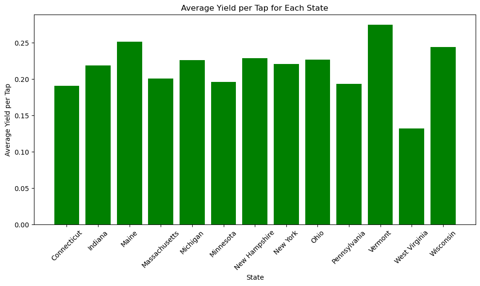

```python
# Create a bar plot
plt.figure(figsize=(10, 6))
plt.bar(average_yield_per_tap['State'], average_yield_per_tap['Yield_per_Tap'], color='green')
plt.xlabel('State')
plt.ylabel('Average Yield per Tap')
plt.title('Average Yield per Tap for Each State')
plt.xticks(rotation=45)
plt.tight_layout()
plt.show()
```

This graph doesn't help much as the data is pretty evenly distributed among the different states, with Vermont being the highest shortly followed by Maine.

Now, lets look at some different data, where we can see the number of taps in every state

```
    - Number of taps: Number of taps used to extract maple syrup
```

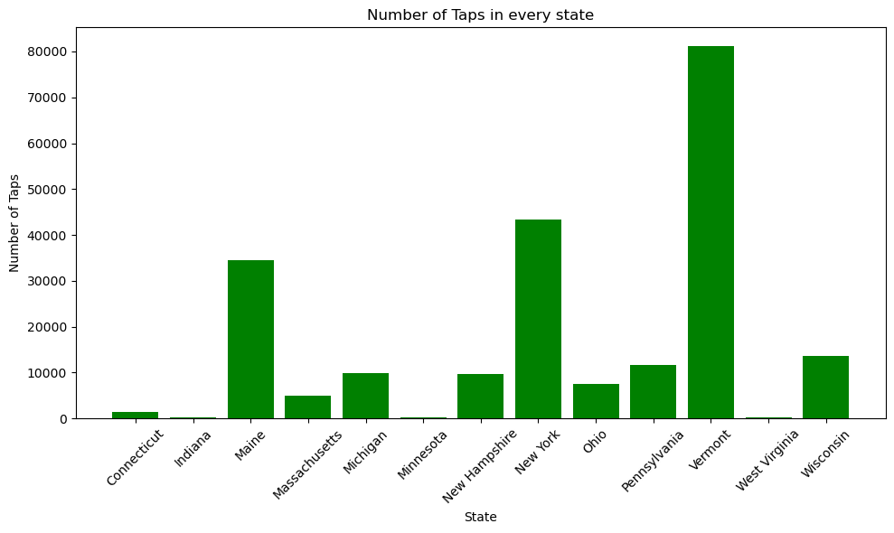

```python
# bar plot for number of taps in every state
plt.figure(figsize=(10, 6))
plt.bar(Num_of_Taps_viz['State'], Num_of_Taps_viz['Num_of_Taps'], color='green')
plt.xlabel('State')
plt.ylabel('Number of Taps')
plt.title('Number of Taps in every state')
plt.xticks(rotation=45)
plt.tight_layout()
plt.show()
```

to put that into a graph, I made the average production of Maple syrup in every state.

*hint: the outlier state is the same one as above*

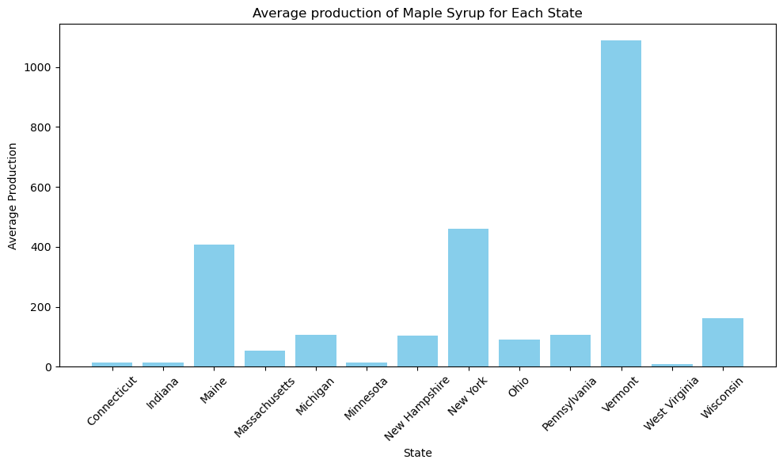

```python
average_production = syrup.groupby('State')['Production'].mean().reset_index()

# Create a bar plot for the average production in every state
plt.figure(figsize=(10, 6))
plt.bar(average_production['State'], average_production['Production'], color='skyblue')
plt.xlabel('State')
plt.ylabel('Average Production')
plt.title('Average production of Maple Syrup for Each State')
plt.xticks(rotation=45)
plt.tight_layout()
plt.show()
```

So, we can establish that Vermont has been a large reason why America was the largest producer of Maple Syrup for a long time.

Now, lets look at the overall rate of production over the years when it comes to the United States.

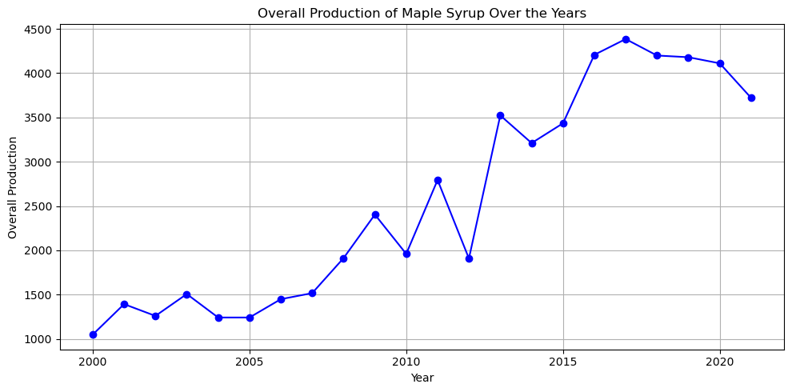

```python
overall_production = syrup.groupby('Year')['Production'].sum().reset_index()

# overall production lineplot
plt.figure(figsize=(10, 5))
years = overall_production['Year']
production = overall_production['Production']
plt.plot(years, production, marker='o', color='b')

plt.xlabel('Year')
plt.ylabel('Overall Production')
plt.title('Overall Production of Maple Syrup Over the Years')
plt.grid(True)
plt.tight_layout()
plt.show()
```

you can see an interesting trend in the rate of production. In general the production of maple syrup has steadlily increased over the years since the year 2000. However, starting from 2017, the production has steadily declined. Today, **Canada is the top producer of Maple Syrup.**

# Second Data Set

## Vermont Statewide Time Series Average temperature from 2000 to 2023

Now comes the second dataset. This dataset is sourced from the [National Oceanic and Atmospheric Administration](https://www.ncei.noaa.gov/access/monitoring/climate-at-a-glance/statewide/time-series) which features large collections of data from different states, different time series, and different values. For the purpose of this project, I downloaded the dataset that showcased the average temperature of Vermont for every year from 2000 to 2023.

First, we need to read in our dataset and look at the data columns we have in this one:

```python
vermont = pd.read_csv('vermontclimate.csv')
```

```python
vermont.info();
```

```
<class 'pandas.core.frame.DataFrame'>
RangeIndex: 24 entries, 0 to 23
Data columns (total 4 columns):
 #   Column   Non-Null Count  Dtype
---  ------   --------------  -----
 0   Date     24 non-null     int64
 1   Month    24 non-null     int64
 2   Value    24 non-null     float64
 3   Anomaly  24 non-null     float64
dtypes: float64(2), int64(2)
memory usage: 900.0 bytes
```

```
    - date refers to the Year
    - Value refers to the temperature in degrees Fahrenheit
```

Lets take a look at a line plot of the average temperature in Vermont over the years.

Below is some similar code used before to draw out the lineplot

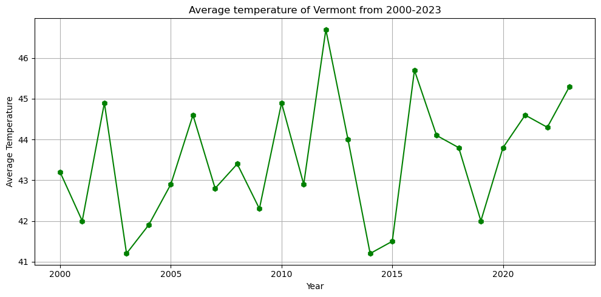

```python
#sns.lineplot(data=vermont, x="Date", y="Value").set_title('Vermonts average yearly climate')
plt.figure(figsize=(10, 5))
plt.plot('Date', 'Value', data=vermont, marker='h', color='g')

plt.xlabel('Year')
plt.ylabel('Average Temperature')
plt.title('Average temperature of Vermont from 2000-2023')
plt.grid(True)
plt.tight_layout()
plt.show()
```

There are two interesting points to note from this graph:

```
1. There is a steep hike in temperature around the year 2012
2. There is a general increase in average temperature in the recent years
```

Now let's combine the two datasets together to visualize the relationship between the two components *(Temperature, Syrup Production)*

Below I have Vermont's production of maple syrup over the years:

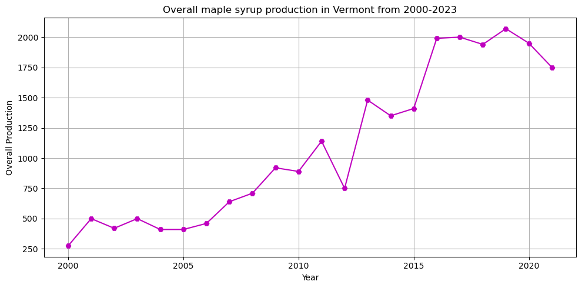

```python
vermont_production = syrup.query("State == 'Vermont'")

plt.figure(figsize=(10, 5))
plt.plot('Year', 'Production', data=vermont_production, marker='H', color='m')

plt.xlabel('Year')
plt.ylabel('Overall Production')
plt.title('Overall maple syrup production in Vermont from 2000-2023')
plt.grid(True)
plt.tight_layout()
```

## So what?

It doesn't seem like a pressing issue, since it's just maple syrup. However, the issue of climate change is certainly a **pressing issue**. Maple syrup production is very temperature sensitive and no matter what technological advancements are introduced to speed the collection of the sap, the temperature and the environment can't be changed. Climate Change comes with many dangers and it can affect something as little as maple syrup production to the point where it becomes a larger part of the issue.

## It can't be that bad...

No, its definitely bad. Climate change can drastically affect the amount of sugar in the sap, the length of time sap can be collected, and it can also encourage the proliferation of invasive species *(Solin, n.d.)*. This is just the tip of the iceberg when it comes to **maple syrup production**. There are so many more affects that will take place and have been due to the increasing climate.

## What can we we do help?

Having that mindset is the first step!

Becoming aware of the Climate Crisis and ways in which it affects all of us is something everyone should learn about

The internet can be your best and worst resource. Make sure articles are well credited when it comes to Climate research. In addition, incorporating small sustainability changes in your lifestyle can make a large impact on our collective future!

Below are some links that will give you a general starting point for your research, but again its just a **starting point**:

- https://www.footprintnetwork.org/our-work/climate-change/
- https://www.epa.gov/climatechange-science
- https://climate.mit.edu/what-we-know-about-climate-change

### Finding my datasets

Finding my datasets where pretty difficult, since there was alot of choices to pick from. Each dataset had potential for stories. However, I found it hard to find sets where I could use the visualizations as part of a narrative. Looking through Kaggle I was able to find my first Dataset which was Maple Syrup production. I found this set interesting as it had alot of data collected over something that seemed to trivial. When I researched further I found that there is actually alot of data on maple syrup production in North America, which makes sense now as it is the largest producer.

Finding the second dataset was a bit more difficult even though I had a clear idea in mind. This time, there was so much data on climate and average changes in temperature that it was hard to find the spefici set I was looking for which was Vermont. If I found datasets, they were not in the .csv format which made it difficult for me to easily import it into the program. I was able to find one that worked and was able to transfer it into a .csv file.

### Counting Context

Both datasets that I got were from free websites. It is important to remember that historically Maple Syrup was collected by the indigenous people of American before colonizers arrived and took over. Now, the maple syrup industry has grown rapidly and many forget it's indigenous roots.

The second dataset from the National Oceanic and Atmospheric Administration is a government organization and has an extensive collection of data and covers a wide range of areas. Taking that into consideration and understanding the potential limitations and biases of that can also help understand the trends in the data.

### Ending notes (CODA)

There was alot of iteration when it came to figuring out the narrative process. In addition, I found it difficult to find datasets that would work with the code in jupyter notebook. I struggled with the aesthetics of visualization since I am not familiar with this language. I had many ideas on how I wanted the visualization to look but it was dfficult to implement them all into the project. However, I enjoyed the process of creating the story through the data. I realized that it is much harder to create the story when there isn't much knowledge on the data itself. I found myself finding more narratives the more I did general research on my topics, and soon the bars and lines had more patterns.

I think there is a alot of different ways to go with this data. For starters, looking into Canadas Maple Syrup production could also paint amore vivid picture of the competition and also looking at their average temperature. It's interesting to consider since Canada is more north and generally more colder. Also, looking at the different trees that sap is generally collected from could also be another story to tell as there is a problem of over planting the popular sugar maple tree, which can be wiped out swiftly from invasive species.

I enjoyed working on this project and feel like I have learned something that I can utilize in future projects as well. Data will always be out there and it is important to create a transparent and accessible way for many (such as myself) to be able to take steps to understand it.

### Works Cited

```
    NOAA. (2019, June 6). National Centers for Environmental Information (NCEI). Noaa.gov. https://www.ncei.noaa.gov/
```

```
    The History of Maple Syrup: From Early North American Days to the Present - Coombs Family Farms. (n.d.). Www.coombsfamilyfarms.com. https://www.coombsfamilyfarms.com/blog/the-history-of-maple-syrup-from-early-north-american-days-to-the-present/
```

```
    From Tree To Table: How Maple Syrup Is Made | Publix Super Market | The Publix Checkout. (n.d.). Retrieved September 27, 2023, from https://blog.publix.com/publix/from-tree-to-table-how-maple-syrup-is-made/
```

```
    Solin, J. J. (n.d.). Maple Syrup and Climate Change. Maple Syrup Program. https://maple.extension.wisc.edu/2022/07/29/maple-syrup-and-climate-change/
```